# Task 1 - Incinerator

Harshrim Pardal

5/25/2021

```r
#tinytex::install_tinytex()
#Importing the dataset
library(readxl)
library(DataExplorer)
data1<-read_xlsx("D:\\RIMA\\MBA\\Christ\\SIP-Outlook\\Data\\Incinerator.xlsx",sheet=1)
str(data1)
```

```
## tibble [321 x 25] (S3: tbl_df/tbl/data.frame)
##  $ year    : num [1:321] 1978 1978 1978 1978 1978 ...
##  $ age     : num [1:321] 48 83 58 11 48 78 22 78 42 41 ...
##  $ agesq   : num [1:321] 2304 6889 3364 121 2304 ...
##  $ nbh     : num [1:321] 4 4 4 4 4 4 4 4 4 4 ...
##  $ cbd     : num [1:321] 3000 4000 4000 4000 4000 3000 4000 3000 3000 3000 ...
##  $ intst   : num [1:321] 1000 1000 1000 1000 2000 2000 2000 2000 2000 2000 ...
##  $ lintst  : num [1:321] 6.91 6.91 6.91 6.91 7.6 ...
##  $ price   : num [1:321] 60000 40000 34000 63900 44000 46000 56000 38500 60500 55000 ...
##  $ rooms   : num [1:321] 7 6 6 5 5 6 6 6 8 5 ...
##  $ area    : num [1:321] 1660 2612 1144 1136 1868 ...
##  $ land    : num [1:321] 4578 8370 5000 10000 10000 ...
##  $ baths   : num [1:321] 1 2 1 1 1 3 2 2 2 2 ...
##  $ dist    : num [1:321] 10700 11000 11500 11900 12100 10000 11700 10200 10500 11000 ...
##  $ ldist   : num [1:321] 9.28 9.31 9.35 9.38 9.4 ...
##  $ wind    : num [1:321] 3 3 3 3 3 3 3 3 3 3 ...
##  $ lprice  : num [1:321] 11 10.6 10.4 11.1 10.7 ...
##  $ y81     : num [1:321] 0 0 0 0 0 0 0 0 0 0 ...
##  $ larea   : num [1:321] 7.41 7.87 7.04 7.04 7.53 ...
##  $ lland   : num [1:321] 8.43 9.03 8.52 9.21 9.21 ...
##  $ y81ldist: num [1:321] 0 0 0 0 0 0 0 0 0 0 ...
##  $ lintstsq: num [1:321] 47.7 47.7 47.7 47.7 57.8 ...
##  $ nearinc : num [1:321] 1 1 1 1 1 1 1 1 1 1 ...
##  $ y81nrinc: num [1:321] 0 0 0 0 0 0 0 0 0 0 ...
##  $ rprice  : num [1:321] 60000 40000 34000 63900 44000 46000 56000 38500 60500 55000 ...
##  $ lrprice : num [1:321] 11 10.6 10.4 11.1 10.7 ...
```

```r
summary(data1)
```

```
##       year           age             agesq            nbh
##  Min.   :1978   Min.   :  0.00   Min.   :    0   Min.   :0.000
##  1st Qu.:1978   1st Qu.:  0.00   1st Qu.:    0   1st Qu.:0.000
##  Median :1978   Median :  4.00   Median :   16   Median :2.000
##  Mean   :1979   Mean   : 18.01   Mean   : 1382   Mean   :2.209
##  3rd Qu.:1981   3rd Qu.: 22.00   3rd Qu.:  484   3rd Qu.:4.000
##  Max.   :1981   Max.   :189.00   Max.   :35721   Max.   :6.000
##       cbd            intst           lintst           price
##  Min.   : 1000   Min.   : 1000   Min.   : 6.908   Min.   : 26000
##  1st Qu.: 9000   1st Qu.: 9000   1st Qu.: 9.105   1st Qu.: 65000
##  Median :14000   Median :16000   Median : 9.680   Median : 85900
##  Mean   :15822   Mean   :16442   Mean   : 9.481   Mean   : 96101
##  3rd Qu.:23000   3rd Qu.:24000   3rd Qu.:10.086   3rd Qu.:120000
##  Max.   :35000   Max.   :34000   Max.   :10.434   Max.   :300000
##      rooms             area           land            baths
##  Min.   : 4.000   Min.   : 735   Min.   :  1710   Min.   :1.00
##  1st Qu.: 6.000   1st Qu.:1560   1st Qu.: 16935   1st Qu.:2.00
##  Median : 7.000   Median :2056   Median : 43560   Median :2.00
##  Mean   : 6.586   Mean   :2107   Mean   : 39630   Mean   :2.34
##  3rd Qu.: 7.000   3rd Qu.:2544   3rd Qu.: 46100   3rd Qu.:3.00
##  Max.   :10.000   Max.   :5136   Max.   :544500   Max.   :4.00
##       dist           ldist             wind            lprice
##  Min.   : 5000   Min.   : 8.517   Min.   : 3.000   Min.   :10.17
##  1st Qu.:13400   1st Qu.: 9.503   1st Qu.: 5.000   1st Qu.:11.08
##  Median :19900   Median : 9.898   Median : 7.000   Median :11.36
##  Mean   :20716   Mean   : 9.837   Mean   : 6.978   Mean   :11.38
##  3rd Qu.:27200   3rd Qu.:10.211   3rd Qu.:11.000   3rd Qu.:11.70
##  Max.   :40000   Max.   :10.597   Max.   :11.000   Max.   :12.61
##       y81             larea           lland           y81ldist
##  Min.   :0.0000   Min.   :6.600   Min.   : 7.444   Min.   : 0.000
##  1st Qu.:0.0000   1st Qu.:7.352   1st Qu.: 9.737   1st Qu.: 0.000
##  Median :0.0000   Median :7.629   Median :10.682   Median : 0.000
##  Mean   :0.4424   Mean   :7.597   Mean   :10.302   Mean   : 4.343
##  3rd Qu.:1.0000   3rd Qu.:7.841   3rd Qu.:10.739   3rd Qu.: 9.820
##  Max.   :1.0000   Max.   :8.544   Max.   :13.208   Max.   :10.569
##     lintstsq         nearinc          y81nrinc          rprice
##  Min.   : 47.72   Min.   :0.0000   Min.   :0.0000   Min.   : 26000
##  1st Qu.: 82.90   1st Qu.:0.0000   1st Qu.:0.0000   1st Qu.: 59000
##  Median : 93.71   Median :0.0000   Median :0.0000   Median : 82000
##  Mean   : 90.48   Mean   :0.2991   Mean   :0.1246   Mean   : 83721
##  3rd Qu.:101.73   3rd Qu.:1.0000   3rd Qu.:0.0000   3rd Qu.:100230
##  Max.   :108.87   Max.   :1.0000   Max.   :1.0000   Max.   :300000
##     lrprice
##  Min.   :10.17
##  1st Qu.:10.99
##  Median :11.31
##  Mean   :11.26
##  3rd Qu.:11.52
##  Max.   :12.61
```

```r
dim(data1)
```

```
## [1] 321  25
```

```r
data1<-na.omit(data1) #removing the records containing null values
dim(data1)
```

```
## [1] 321  25
```

```r
#The dimensions are same after removing the records containing null values - thus there are no records containing null values
#Explore
create_report(data1)
```

```
##
##
## processing file: report.rmd
```

[output not shown]

[output not shown]

[output not shown]

[output not shown]

[output not shown]

[output not shown]

[output not shown]

```
## output file: C:/Users/harsh/OneDrive/Desktop/RMarkdown/report.knit.md
```

[output not shown]

```
##
## Output created: report.html
```

```r
#Loading required packages
library(tidyverse)
```

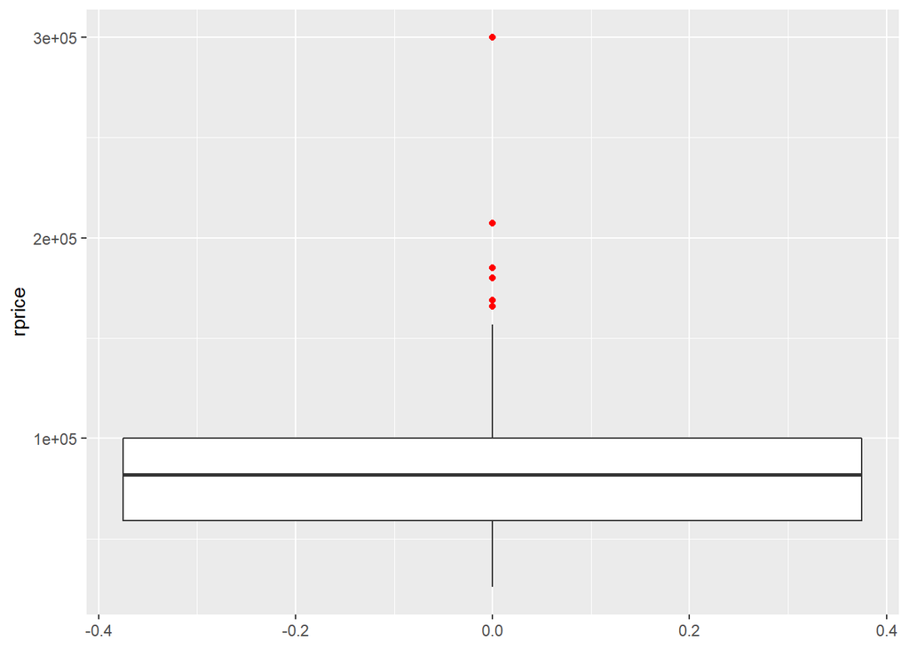

```r
library(dplyr)
library(ggplot2)
library(lmtest)
#library(estimatr)
library(car) #vif
library(lmtest)
library(modelr)
library(broom)
#Checking for outliers in the rprice variable
ggplot(data=data1,aes(y=rprice))+geom_boxplot(outlier.colour="red",outlier.size=1.5)
```

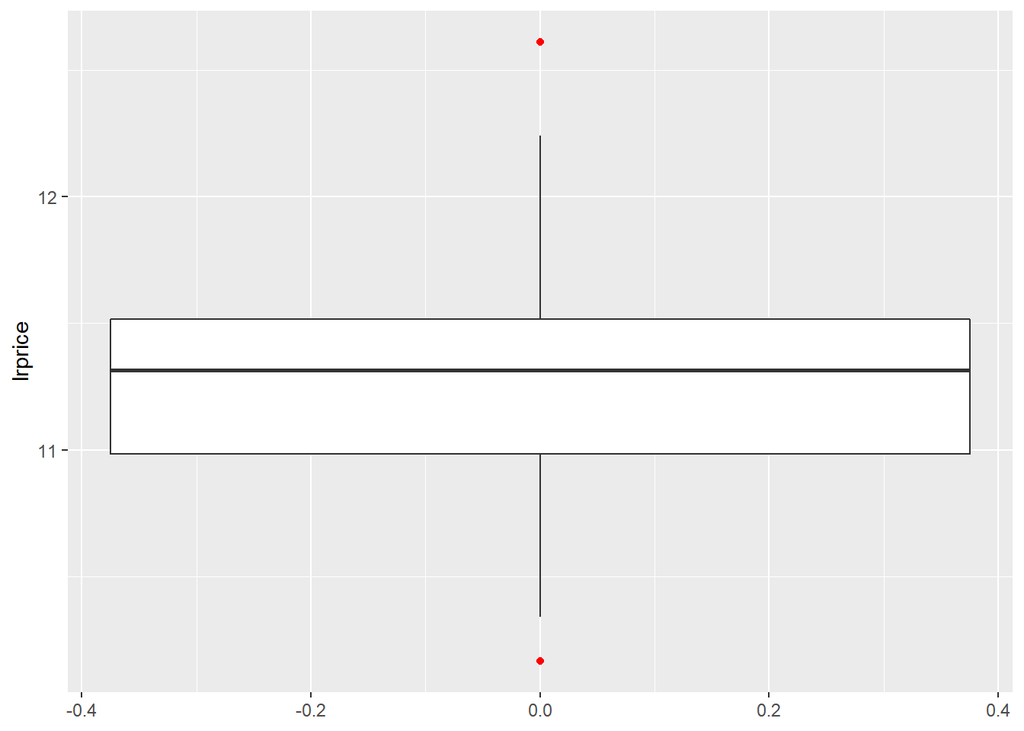

```r
#The boxplot of rprice variable shows that there are some outliers.
#Since we have outliers in our dependent or independent variables, a log transformation could reduce the influence of those observations
ggplot(data=data1,aes(y=lrprice))+geom_boxplot(outlier.colour="red",outlier.size=1.5)
```

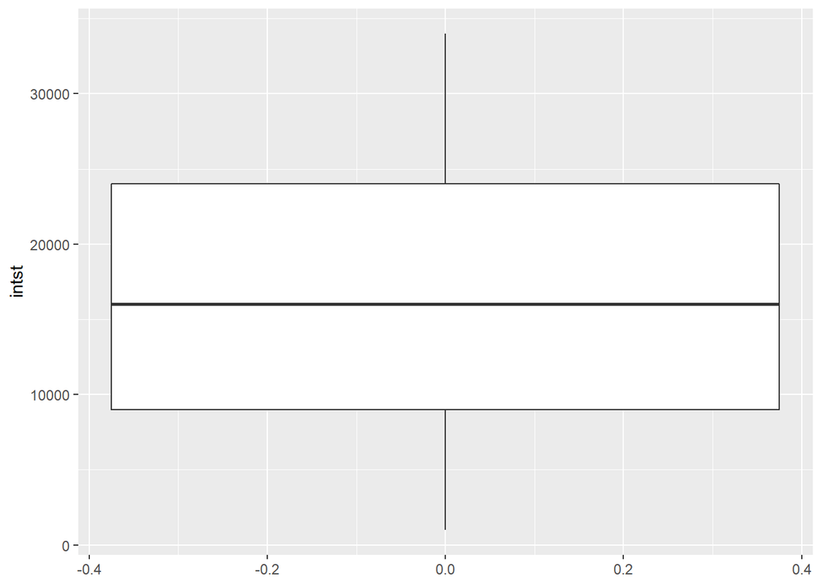

```r
#Checking for outliers in the intst variable
ggplot(data=data1,aes(y=intst))+geom_boxplot(outlier.colour="red",outlier.size=1.5)
```

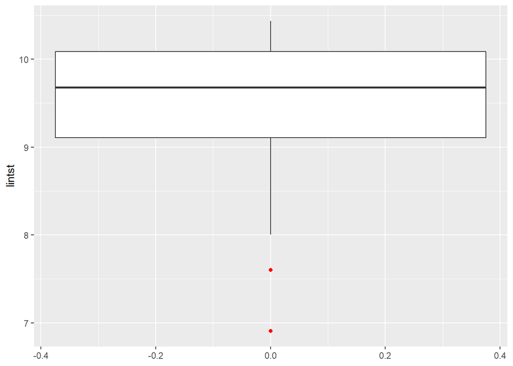

```r
ggplot(data=data1,aes(y=lintst))+geom_boxplot(outlier.colour="red",outlier.size=1.5)
```

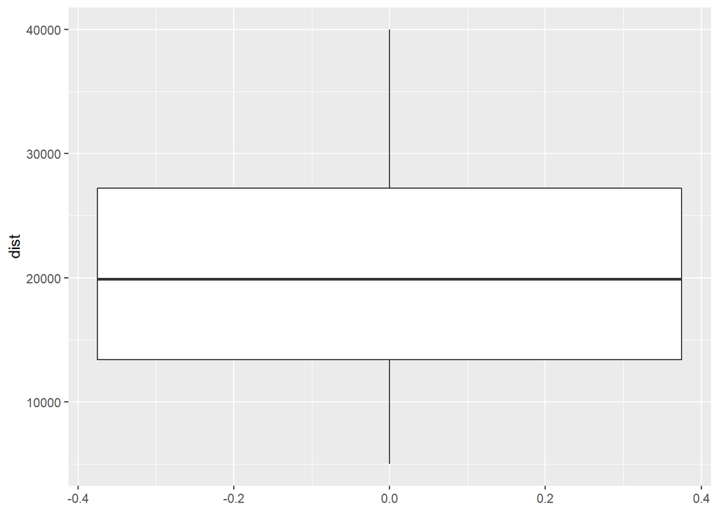

```r
#Checking for outliers in the dist variable
ggplot(data=data1,aes(y=dist))+geom_boxplot(outlier.colour="red",outlier.size=1.5)
```

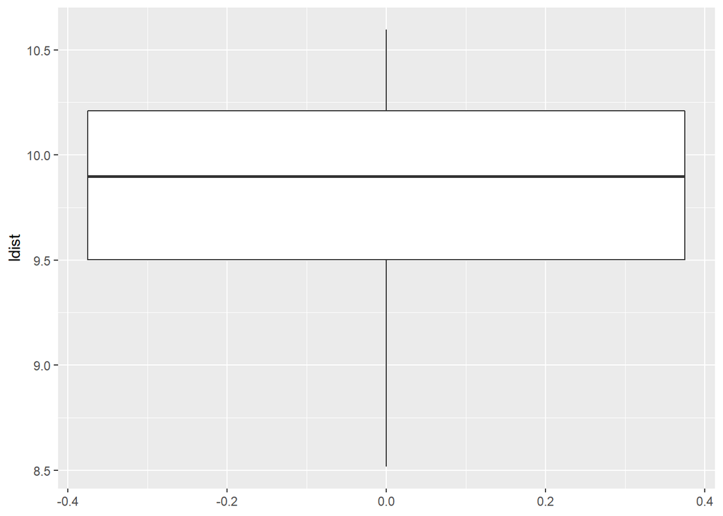

```r
ggplot(data=data1,aes(y=ldist))+geom_boxplot(outlier.colour="red",outlier.size=1.5)
```

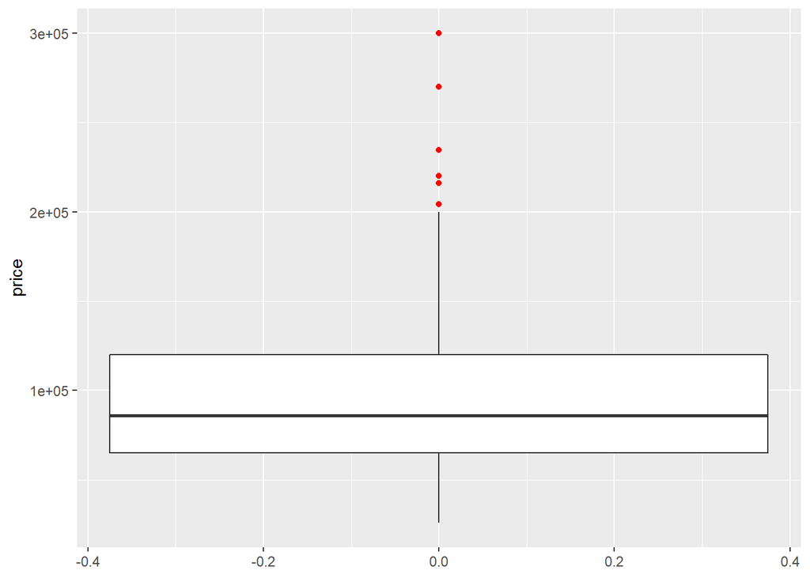

```r
#Checking for outliers in the price variable
ggplot(data=data1,aes(y=price))+geom_boxplot(outlier.colour="red",outlier.size=1.5)
```

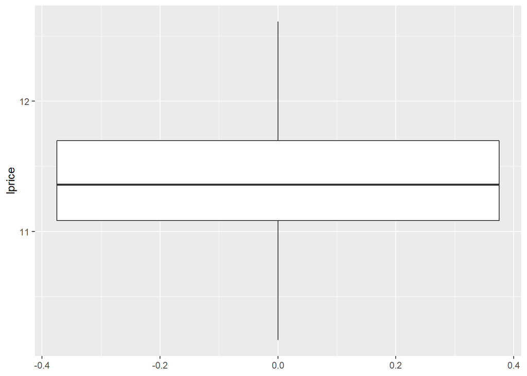

```r
ggplot(data=data1,aes(y=lprice))+geom_boxplot(outlier.colour="red",outlier.size=1.5)
```

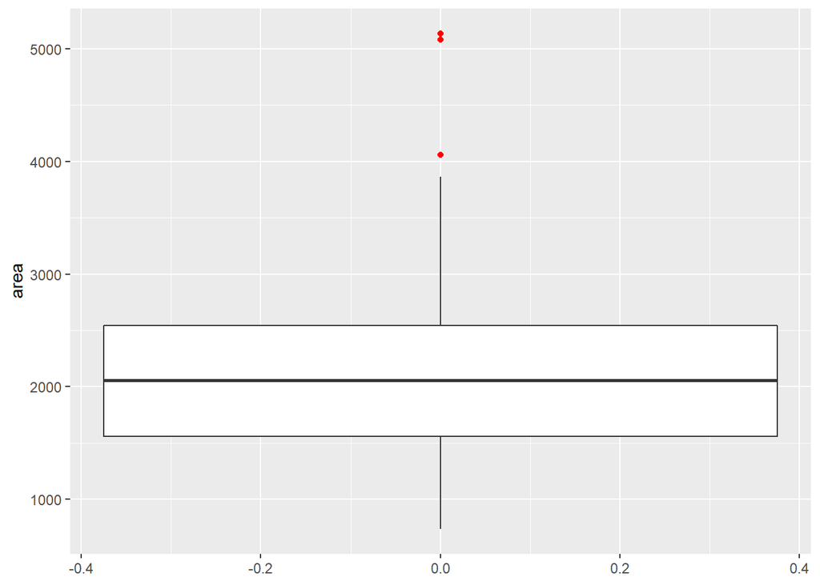

```r
#Checking for outliers in the area variable
ggplot(data=data1,aes(y=area))+geom_boxplot(outlier.colour="red",outlier.size=1.5)
```

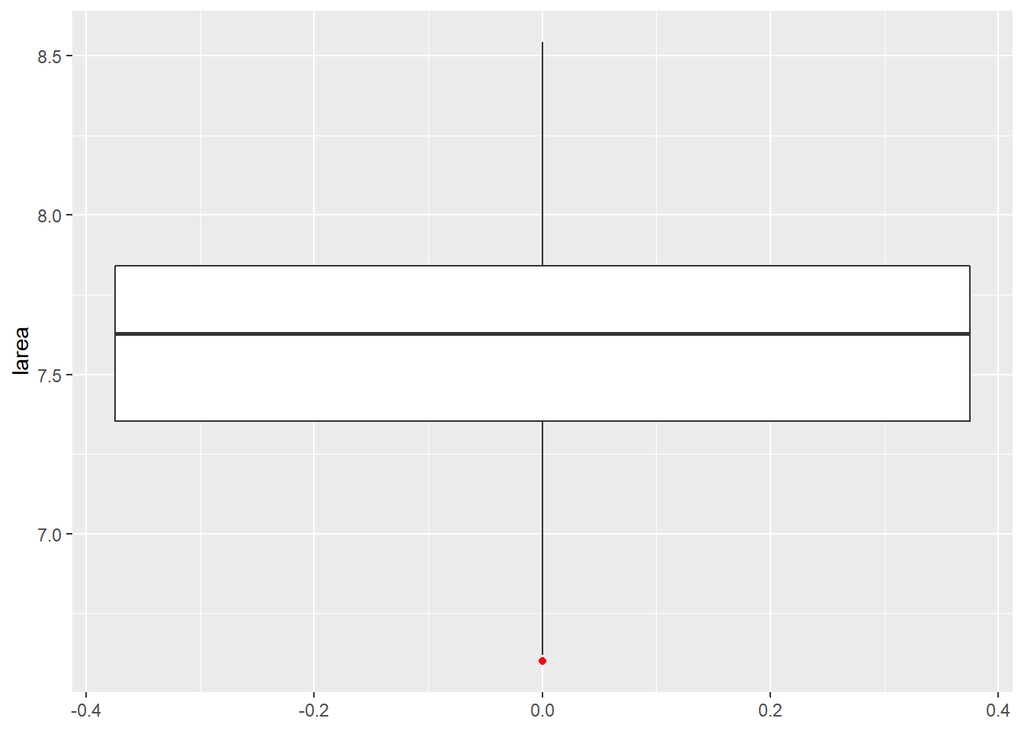

```r
ggplot(data=data1,aes(y=larea))+geom_boxplot(outlier.colour="red",outlier.size=1.5)
```

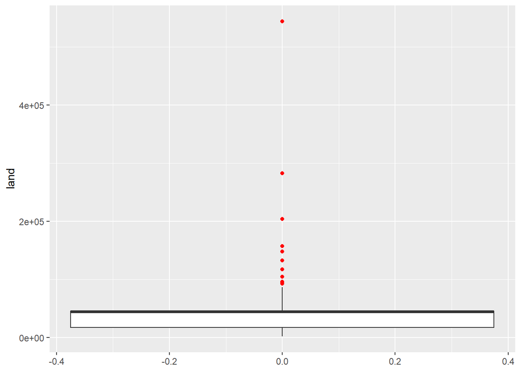

```r
#Checking for outliers in the land variable
ggplot(data=data1,aes(y=land))+geom_boxplot(outlier.colour="red",outlier.size=1.5)
```

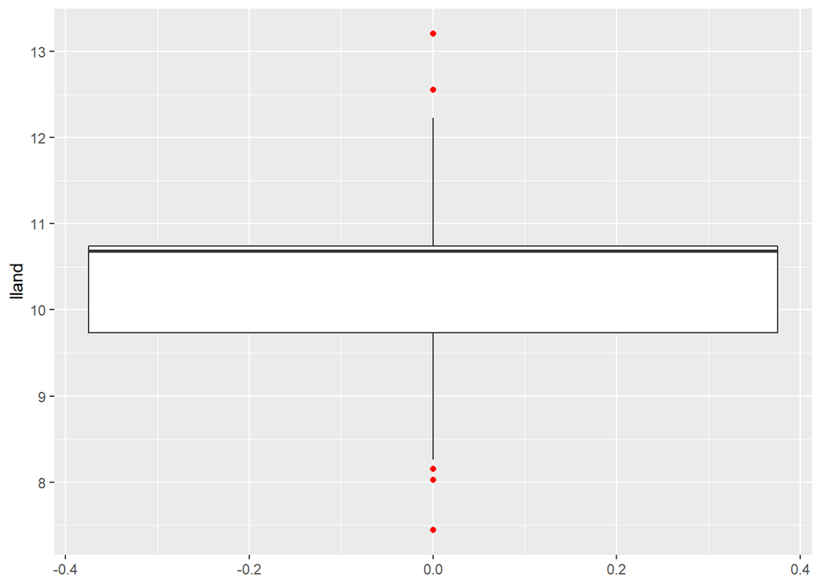

```r
ggplot(data=data1,aes(y=lland))+geom_boxplot(outlier.colour="red",outlier.size=1.5)
```

Problem Statement 1 - What factors affect the house price. Problem Statement 2 - Predict the price of a house depending on the available values of other parameters

**MODEL DEVELOPMENT**

```r
library(caTools)
#Creating a subset of 70% data
set.seed(100)
split1<-sample.split(data1$age, SplitRatio=0.7)
data1train<-subset(data1, split1==TRUE)
data1test<-subset(data1, split1==FALSE)
```

**EXPLANATION**

The above code creates a subset of the original Incinerator dataset and divides it into two parts - 70% training dataset and 30% testing dataset. The set.seed is used to generate random numbers

The training dataset is stored in data1train The testing dataset is stored in data1test

```r
#Building the regression model
reg1<-lm(lrprice~age+nbh+cbd+lintst+rooms+larea+lland+baths+ldist, data= data1train)
summary(reg1)
```

```
##
## Call:
## lm(formula = lrprice ~ age + nbh + cbd + lintst + rooms + larea +
##     lland + baths + ldist, data = data1train)
##
## Residuals:
##      Min       1Q   Median       3Q      Max
## -1.30382 -0.10275 -0.00014  0.12766  0.64953
##
## Coefficients:
##               Estimate Std. Error t value Pr(>|t|)
## (Intercept)  4.012e+00  9.736e-01   4.121 5.32e-05 ***
## age         -2.929e-03  5.141e-04  -5.699 3.81e-08 ***
## nbh         -1.180e-02  7.877e-03  -1.498 0.135641
## cbd         -1.686e-05  6.181e-06  -2.729 0.006867 **
## lintst       4.889e-02  4.907e-02   0.996 0.320200
## rooms        3.848e-02  2.198e-02   1.751 0.081351 .
## larea        4.360e-01  6.633e-02   6.574 3.46e-10 ***
## lland        9.878e-02  2.939e-02   3.360 0.000916 ***
## baths        1.081e-01  3.464e-02   3.120 0.002045 **
## ldist        2.334e-01  7.481e-02   3.120 0.002051 **
## ---
## Signif. codes:  0 '***' 0.001 '**' 0.01 '*' 0.05 '.' 0.1 ' ' 1
##
## Residual standard error: 0.2236 on 222 degrees of freedom
## Multiple R-squared:  0.7014, Adjusted R-squared:  0.6893
## F-statistic: 57.94 on 9 and 222 DF,  p-value: < 2.2e-16
```

```r
#prediction and rmse
predicted1<-predict(reg1,data1test)
predicted1
```

```
##        1        2        3        4        5        6        7        8
## 10.93050 10.96515 10.86906 10.59171 10.96803 10.63484 11.15360 11.40372
##        9       10       11       12       13       14       15       16
## 11.64031 11.16548 10.89855 10.52301 11.57272 11.36792 11.47232 11.39903
##       17       18       19       20       21       22       23       24
## 11.39657 11.36921 11.44646 11.41255 11.17193 11.59718 10.96414 11.42645
##       25       26       27       28       29       30       31       32
## 11.27849 11.30932 11.40199 11.41269 11.10342 11.54997 11.13348 10.91362
##       33       34       35       36       37       38       39       40
## 11.01208 10.82236 11.63692 11.51131 11.51318 11.44913 11.27743 11.37187
##       41       42       43       44       45       46       47       48
## 11.29606 11.52799 11.37984 11.10372 11.62437 11.33499 11.68012 11.51918
##       49       50       51       52       53       54       55       56
## 11.59586 11.49118 11.60929 10.56559 10.79938 10.85786 11.03205 11.39711
##       57       58       59       60       61       62       63       64
## 11.53483 11.40287 10.62746 10.66208 10.97800 11.69255 11.83445 11.65693
##       65       66       67       68       69       70       71       72
## 11.61688 11.45585 11.05422 11.63618 11.65824 11.47325 11.00377 11.64166
##       73       74       75       76       77       78       79       80
## 11.57173 11.48948 11.43443 11.49879 11.63195 11.68640 11.57106 10.94909
##       81       82       83       84       85       86       87       88
## 11.49379 11.01297 11.14127 11.50765 11.07897 11.12070 11.56807 11.04504
##       89
## 11.58112
```

```r
dim(predicted1)
```

```r
library(Metrics)
#Metrics::rmse(data1test$e..g.km.,predicted1)
rmse(predicted1,data1test$lrprice)
```

```
## [1] 0.1824635
```

```r
AIC(reg1)
```

```
## [1] -24.91996
```

```r
BIC(reg1)
```

```
## [1] 12.99415
```

```r
#ANOVA Table
ano<-anova(reg1)
ano
```

```
## Analysis of Variance Table
##
## Response: lrprice
##            Df  Sum Sq Mean Sq  F value    Pr(>F)
## age         1  6.3919  6.3919 127.8804 < 2.2e-16 ***
## nbh         1  1.2611  1.2611  25.2293 1.045e-06 ***
## cbd         1  3.1396  3.1396  62.8124 1.094e-13 ***
## lintst      1  1.4439  1.4439  28.8883 1.935e-07 ***
## rooms       1  5.6216  5.6216 112.4692 < 2.2e-16 ***
## larea       1  6.5728  6.5728 131.4986 < 2.2e-16 ***
## lland       1  0.5513  0.5513  11.0296 0.0010483 **
## baths       1  0.5959  0.5959  11.9223 0.0006641 ***
## ldist       1  0.4865  0.4865   9.7322 0.0020507 **
## Residuals 222 11.0964  0.0500
## ---
## Signif. codes:  0 '***' 0.001 '**' 0.01 '*' 0.05 '.' 0.1 ' ' 1
```

**EXPLANATION** The dependent Variable(DV) in this model is lrprice which is a scaled variable. The independent variables used are age(Age of House),nbh(Neighborhood) cbd(Distance to Central Bus dstrct,feet) , lintst(Log of distance to interstate),rooms(Number of rooms),larea(Log of square footage of house),lland(Log of sqaure footage of lot),baths(Number of batrooms),ldist(Log of distance from house to incinerator)

Using this these variables and the training dataset regression model is built p-value>0.05 —accept null hypothesis p-value<0.05—reject null hypothesis

Ho:Model is not good fit , Ha: Model good fit

From the output , we get a p-value of 2.2e-16 which is <0.05 Thus, Null Hypothesis is rejected. Thus model is a good fit.

H0:Variable has no impact on lrprice (Price of House) Ha:Variable has impact on Price of House From the output the Pr(>|t|) values of the Chosen IVs are: Age - 3.81e-08 —->Null Hypothesis Rejected nbh - 0.135641 —->Null Hypothesis cannot be rejected cbd - 0.006867 —->Null Hypothesis is rejected lintst - 0.320200 —->Null Hypothesis cannot be rejected rooms- 0.081351—->Null Hypothesis cannot be Rejected larea - 3.46e-10—->Null Hypothesis Rejected lland - 0.000916 —->Null Hypothesis Rejected baths - 0.002045 —->Null Hypothesis Rejected ldist - 0.002051 —->Null Hypothesis Rejected

Conclusion: Age of House and Log of Square Footage of House has highest impact on price of house, followed by (in descending order of importance) lland(Log of sqaure lot) ,baths(NUmber of bathrooms), ldist(Log of distance to incinerator),cbd (Distance to central bus dstrct)

Neigborhood , lintst,rooms has no impact on house price

Adjusted R square and R square: R square is coefficient of determination- 0.7014 i.e. 70.14% . The selected variable (IVs) create 70.14% variation in the Dependent Variable -House Price

Adjusted R square: As there are more than one IV thus Adjusted R square should be considered, .6893 i.e. 68.93% . The selected IVs create 68.93% variation in the Price of House . This indicates that dataset containing a few more variables should also be collected in order to get better prediction model

RMSE is 0.1824635 which is less. Higher the RMSE, more improper the model is. To lower the RMSE more, more data should be collected so that the training and testing data is more. In this case , the testing dataset is very small due to which the RMSE is also less. Thus in order to get more accurte results , more data needs to be collected

Regression equation: House Price= 4.012e+00 - 2.929e-03 * age -1.180e-02 * nbh -1.686e-05 * cbd + 4.889e-02 * lintst + 3.848e-02 * rooms+4.360e-01 * larea + 9.878e-02 * lland + 1.081e-01 * baths + 2.334e-01 * ldist

```r
#Multicollinearity with respect to Model
library(car)
vif(reg1)
```

```
##       age       nbh       cbd    lintst     rooms     larea     lland     baths
##  1.476321  1.325202 15.047801  7.574868  1.807244  2.244544  2.893514  3.259804
##     ldist
##  6.380803
```

```r
#Building second model by dropping variables having no impact on house price and variables having high multicollinearity
reg2<-lm(lrprice~age+larea+lland+baths, data= data1train)
summary(reg2)
```

```
##
## Call:
## lm(formula = lrprice ~ age + larea + lland + baths, data = data1train)
##
## Residuals:
##     Min      1Q  Median      3Q     Max
## -1.2304 -0.1189 -0.0017  0.1375  0.7218
##
## Coefficients:
##               Estimate Std. Error t value Pr(>|t|)
## (Intercept)  6.6067863  0.4840129  13.650  < 2e-16 ***
## age         -0.0025605  0.0004938  -5.185 4.77e-07 ***
## larea        0.4541769  0.0674831   6.730 1.37e-10 ***
## lland        0.0855798  0.0216328   3.956 0.000102 ***
## baths        0.1562140  0.0324448   4.815 2.69e-06 ***
## ---
## Signif. codes:  0 '***' 0.001 '**' 0.01 '*' 0.05 '.' 0.1 ' ' 1
##
## Residual standard error: 0.2321 on 227 degrees of freedom
## Multiple R-squared:  0.6709, Adjusted R-squared:  0.6651
## F-statistic: 115.7 on 4 and 227 DF,  p-value: < 2.2e-16
```

```r
vif(reg2)
```

```
##      age    larea    lland    baths
## 1.263894 2.155239 1.453913 2.652838
```

```r
#prediction and rmse
predicted2<-predict(reg2,data1test)
predicted2
```

```
##        1        2        3        4        5        6        7        8
## 11.05876 10.96603 10.90041 10.60801 10.86707 10.68745 11.10366 11.50057
##        9       10       11       12       13       14       15       16
## 11.54092 11.13425 10.97549 10.51472 11.54320 11.33443 11.53130 11.46119
##       17       18       19       20       21       22       23       24
## 11.46076 11.43478 11.42902 11.49406 11.14414 11.59134 11.02802 11.42584
##       25       26       27       28       29       30       31       32
## 11.26264 11.40389 11.52198 11.50374 11.07776 11.58434 11.11259 10.83964
##       33       34       35       36       37       38       39       40
## 11.06569 10.85425 11.61430 11.48123 11.50016 11.38547 11.23576 11.26696
##       41       42       43       44       45       46       47       48
## 11.23506 11.53573 11.38460 11.12700 11.55692 11.23021 11.60470 11.44249
##       49       50       51       52       53       54       55       56
## 11.51828 11.41479 11.54708 10.44755 10.70450 10.80785 10.97518 11.33375
##       57       58       59       60       61       62       63       64
## 11.47525 11.36855 10.64594 10.59835 10.85558 11.61349 11.81044 11.58752
##       65       66       67       68       69       70       71       72
## 11.62690 11.54148 10.99544 11.66782 11.65172 11.50633 10.94480 11.62912
##       73       74       75       76       77       78       79       80
## 11.57152 11.50189 11.54229 11.49085 11.61049 11.66807 11.54387 10.87385
##       81       82       83       84       85       86       87       88
## 11.43003 10.90301 11.05814 11.39993 11.11399 11.09319 11.65630 10.98596
##       89
## 11.50111
```

```r
dim(predicted2)
```

```r
library(Metrics)
#Metrics::rmse(data1test$e..g.km.,predicted1)
rmse(predicted2,data1test$lrprice)
```

```
## [1] 0.1916422
```

```r
AIC(reg2)
```

```
## [1] -12.35163
```

```r
BIC(reg2)
```

```
## [1] 8.328791
```

**EXPLANATION**

Model 2 - vif output - No need to drop any further IV

The dependent Variable(DV) in this model is lrprice which is a scaled variable. The independent variables used are age(Age of House),larea(Log of square footage of house),lland(Log of sqaure footage of lot),baths(Number of batrooms)

Using this these variables and the training dataset regression model is built p-value>0.05 —accept null hypothesis p-value<0.05—reject null hypothesis

Ho:Model is not good fit , Ha: Model good fit

From the output , we get a p-value of 2.2e-16 which is <0.05 Thus, Null Hypothesis is rejected. Thus model is a good fit.

Adjusted R square and R square: R square is coefficient of determination- 0.6709 i.e. 67.09% . The selected variable (IVs) create 67.09% variation in the Dependent Variable -House Price

Adjusted R square: As there are more than one IV thus Adjusted R square should be considered, 0.6651 i.e. 66.51% . The selected IVs create 66.51% variation in the Price of House . This indicates that dataset containing a few more variables should also be collected in order to get better prediction model

RMSE is 0.1916422 which is less. Higher the RMSE, more improper the model is. To lower the RMSE more, more data should be collected so that the training and testing data is more. In this case , the testing dataset is very small due to which the RMSE is also less. Thus in order to get more accurte results , more data needs to be collected

Regression equation: House Price= 6.606783 - -0.0025605 * age = 0.4541769 * larea + 0.0855798 * lland + 0.1562140 * baths

Conclusion on beta coefficients: For each unit increase in age , the house of price will decrease by 0.0025605 For each unit increase in number of batrooms, the house price will increase by 0.1562140 For each unit increase in larea ,the house price will increase by 0.4541769 For each unit increase in lland ,the house price will increase by 0.0855798

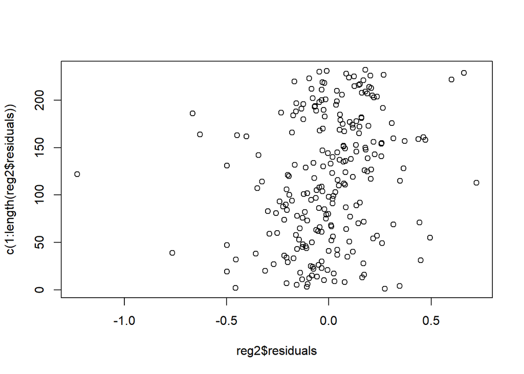

```r
#Heteroscedasticity of residual
#randomness in residual
plot(reg2$residuals,c(1:length(reg2$residuals)))
```

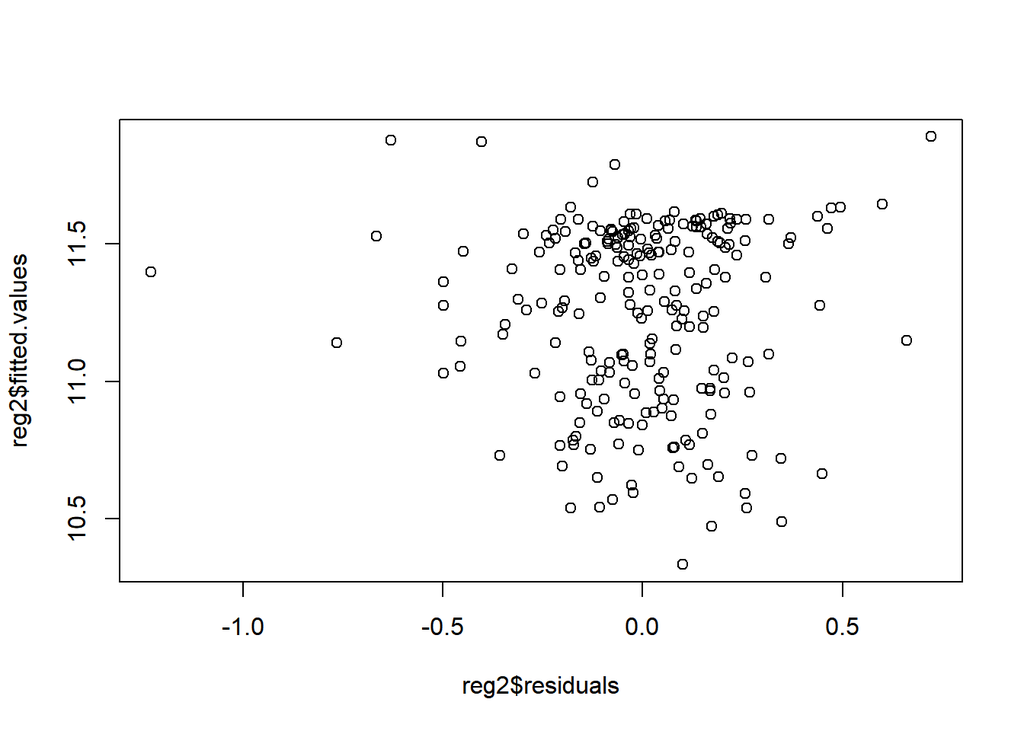

```r
#Heteroscadisticy-
plot(reg2$residuals,reg2$fitted.values)
```

```r
library(lmtest)
library(fBasics)
library(moments)
bptest(reg2)
```

```
##
##  studentized Breusch-Pagan test
##
## data:  reg2
## BP = 8.5039, df = 4, p-value = 0.07477
```

**EXPLANATION** Heteroscedasticity means unequal scatter and produces a distinctive fan or cone shape in residual plots . Specifically, heteroscedasticity is a systematic change in the spread of the residuals over the range of measured value.

The test statistic is 8.5039 and the corresponding p-value is 0.07477. Since the p-value is not less than 0.05, we cannot reject the null hypothesis. We do not have sufficient evidence to say that heteroscedasticity is present in the regression model.

```r
#Normality of Residual
reg2$coefficients
```

```
##  (Intercept)          age        larea        lland        baths
##  6.606786293 -0.002560533  0.454176869  0.085579812  0.156214014
```

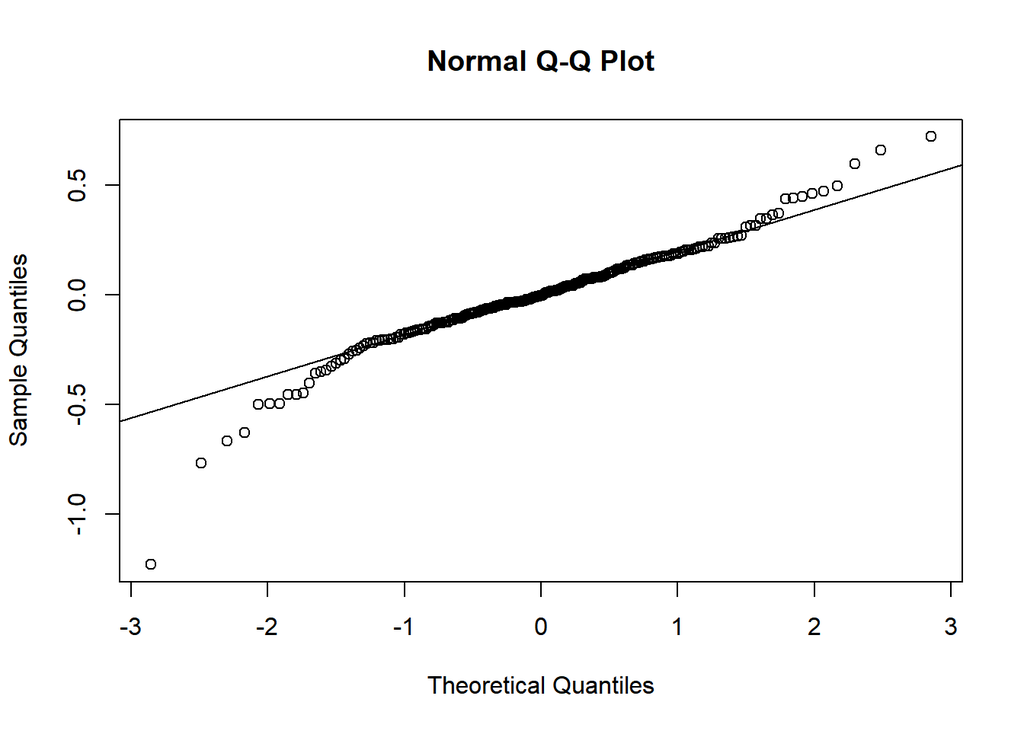

```r
x<-reg2$residuals
qqnorm(x)
qqline(x)
```

```r
shapiro.test(x)
```

```
##
##  Shapiro-Wilk normality test
##
## data:  x
## W = 0.95022, p-value = 3.744e-07
```

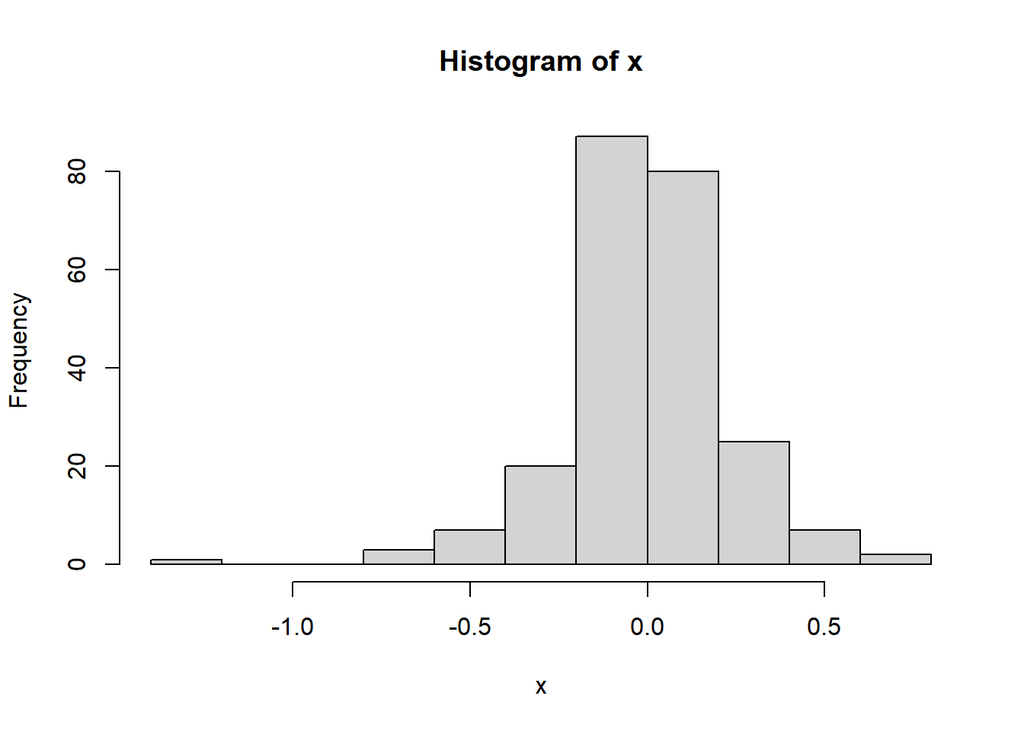

```r
hist(x)
```

**EXPLANATION** Shapiro Test for Normality: Null hypothesis: Data is normally distributed Alternate Hypothesis: Data is not normally distributed

```r
#Autocorrelation
library(lmtest)
dwtest(reg2)
```

```
##
##  Durbin-Watson test
##
## data:  reg2
## DW = 1.5805, p-value = 0.000529
## alternative hypothesis: true autocorrelation is greater than 0
```

**EXPLANATION** Autocorrelation occurs when the residuals are not independent from each other. The null hypothesis of the Durbin Watson test (Ho) is that there is no correlation among residuals, i.e., they are independent. The alternative hypothesis (Ha) is that residuals are autocorrelated.

we see that the resulting p-value is not greater than 0.05, and so we reject the null hypothesis. The D-W statistic for this model of 1.5805 which indicates a less positive correlation in the residuals data. In order to solve this and remove autocorrelation some more missing predictors(IVs) should be added to the regression model

```r
#Problem Statement 3 -Does vicinity to an incinerator have impact on house price
#Problem Statement 4 -Does the effect of vicinity to incinerator on house price have same effect over time
model1<- lm(lrprice ~ nearinc+ ldist, data = data1train)

summary(model1)
```

```
##
## Call:
## lm(formula = lrprice ~ nearinc + ldist, data = data1train)
##
## Residuals:
##      Min       1Q   Median       3Q      Max
## -1.17186 -0.20663 -0.01063  0.19555  1.53948
##
## Coefficients:
##             Estimate Std. Error t value Pr(>|t|)
## (Intercept)  9.67626    0.88977  10.875   <2e-16 ***
## nearinc     -0.22789    0.09231  -2.469   0.0143 *
## ldist        0.16828    0.08798   1.913   0.0570 .
## ---
## Signif. codes:  0 '***' 0.001 '**' 0.01 '*' 0.05 '.' 0.1 ' ' 1
##
## Residual standard error: 0.358 on 229 degrees of freedom
## Multiple R-squared:  0.2102, Adjusted R-squared:  0.2033
## F-statistic: 30.48 on 2 and 229 DF,  p-value: 1.837e-12
```

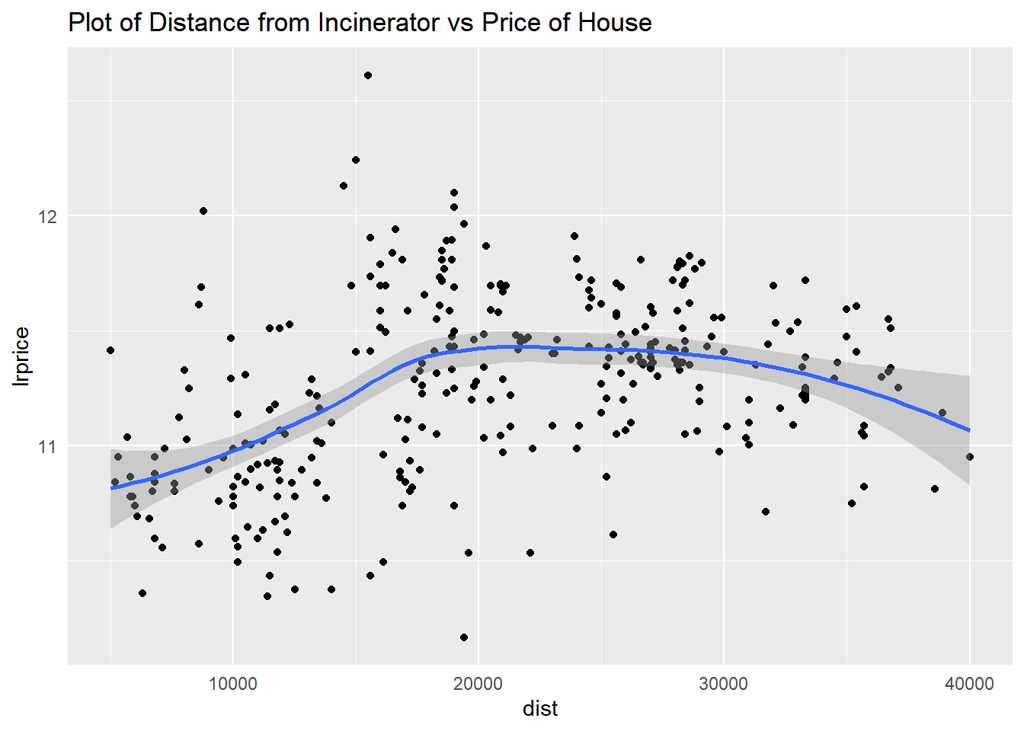

```r
ggplot(aes(x = dist, y = lrprice), data = data1) + geom_point()+geom_smooth()+ggtitle("Plot of Distance from Incinerator vs Price of House")  + theme(axis.ticks =element_blank())
```

```r
#To see whether house prices changed over time we use difference-in-difference model.

model2 <- lm(lrprice ~ nearinc + y81 + y81ldist, data = data1train)
summary(model2)
```

```
##
## Call:
## lm(formula = lrprice ~ nearinc + y81 + y81ldist, data = data1train)
##
## Residuals:
##      Min       1Q   Median       3Q      Max
## -1.11435 -0.19974  0.00857  0.19091  1.66418
##
## Coefficients:
##             Estimate Std. Error t value Pr(>|t|)
## (Intercept) 11.28020    0.03735 302.016  < 2e-16 ***
## nearinc     -0.33284    0.05853  -5.687 3.95e-08 ***
## y81         -0.67458    0.83861  -0.804    0.422
## y81ldist     0.08743    0.08549   1.023    0.308
## ---
## Signif. codes:  0 '***' 0.001 '**' 0.01 '*' 0.05 '.' 0.1 ' ' 1
##
## Residual standard error: 0.3492 on 228 degrees of freedom
## Multiple R-squared:  0.2519, Adjusted R-squared:  0.2421
## F-statistic: 25.59 on 3 and 228 DF,  p-value: 2.628e-14
```

** EXPLANATION ** #model1 The dependent Variable(DV) in this model is lrprice which is a scaled variable. The independent variables used are nearinc and ldist

Using this these variables and the training dataset regression model is built p-value>0.05 —accept null hypothesis p-value<0.05—reject null hypothesis

Ho:Model is not good fit , Ha: Model good fit

From the output , we get a p-value of 1.837e-12 which is <0.05 Thus, Null Hypothesis is rejected. Thus model is a good fit.

#model2 From the output we see that y81ldist is not significant which is same as seen in model 1 where ldist was not significant . Thus we can say that there is no significant difference on house prices between the years.

```r
#Problem Statement 5 -  Determine average number of rooms and bathrooms for each neighborhood and also determine min and max house price according to the number of bathrooms
data1$nbh <- as.factor(data1$nbh)
data1$nbh
```

```
##   [1] 4 4 4 4 4 4 4 4 4 4 4 0 0 0 0 4 4 4 4 4 4 4 2 2 2 2 2 2 2 2 2 4 4 0 0 0 4
##  [38] 4 4 4 0 4 4 0 0 0 0 0 1 0 0 0 4 4 0 0 0 4 4 4 4 0 0 0 0 0 1 1 1 1 1 1 1 1
##  [75] 1 1 6 6 6 6 6 6 6 6 6 6 6 6 1 1 1 1 6 6 6 0 0 0 0 0 5 5 5 5 5 5 5 5 5 5 5
## [112] 5 2 2 2 2 2 2 2 2 5 5 5 5 5 5 5 0 0 0 0 0 0 2 2 2 2 2 2 2 2 2 2 2 2 2 2 3
## [149] 0 3 3 3 0 0 0 0 0 0 4 4 4 4 0 6 6 0 0 0 0 0 0 0 0 0 0 0 0 0 0 4 4 4 4 4 4
## [186] 0 0 0 0 0 4 4 4 4 4 1 2 4 4 0 0 0 0 0 0 0 4 0 0 0 0 0 0 0 0 0 0 0 0 0 0 0
## [223] 0 0 1 1 1 1 1 1 4 4 4 4 0 0 0 0 0 0 0 0 0 6 6 6 6 6 6 6 6 1 1 1 1 1 6 6 6
## [260] 6 6 6 0 2 2 2 2 2 2 5 5 5 5 5 5 5 5 0 0 0 0 0 0 0 0 0 0 0 2 2 2 2 2 2 2 2
## [297] 2 0 3 3 3 0 0 0 0 0 0 0 4 4 4 4 4 4 0 0 0 6 0 0 0
## Levels: 0 1 2 3 4 5 6
```

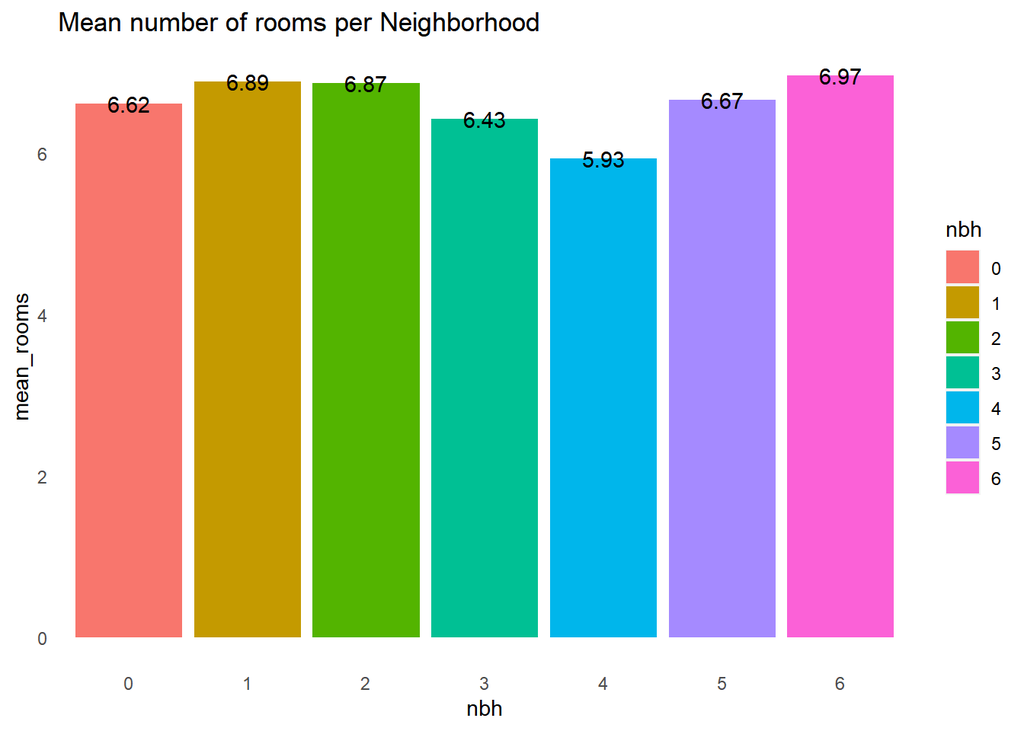

```r
data2<-data1 %>% group_by(nbh) %>% summarise(mean_rooms = mean(rooms))

ggplot(aes(x = nbh, y = mean_rooms,fill=nbh), data = data2) + geom_bar(stat = "identity")+geom_text(aes(label = signif(mean_rooms, digits = 3), nudge_y=1))+ggtitle("Mean number of rooms per Neighborhood") + theme(axis.ticks =element_blank(),
                          panel.background = element_blank())
```

Interpretation- Neighborhood 4 has minimum average number of rooms per neighborhood - 5.93 Neighborhood 6 has maximum average number of rooms per neighborhood - 6.97

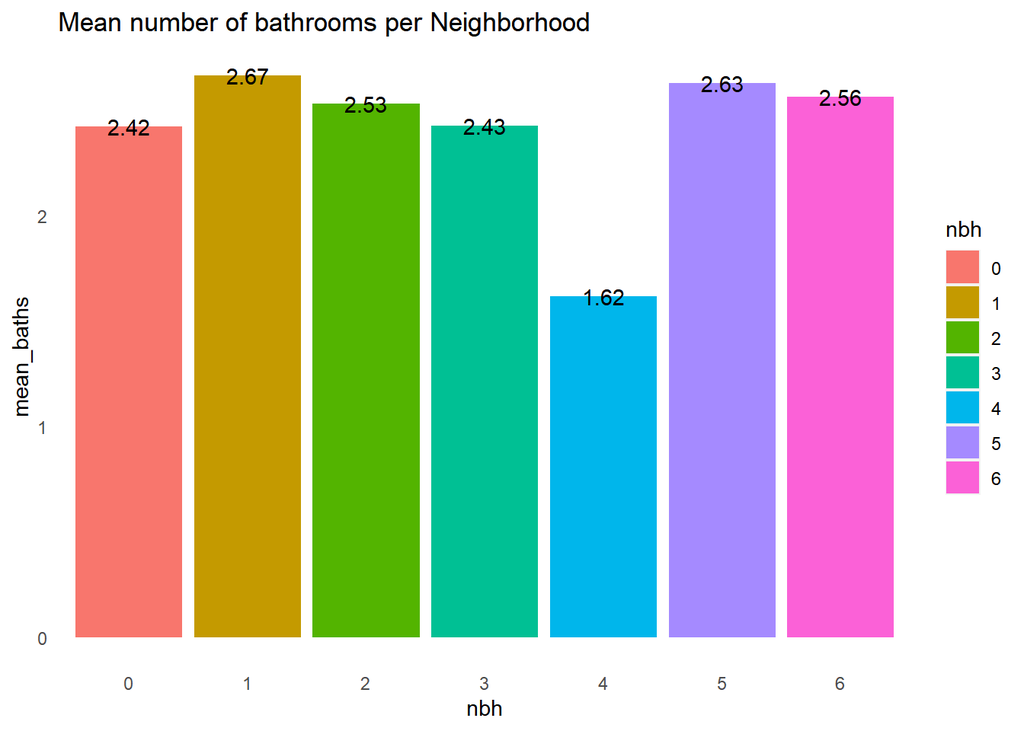

```r
data3<-data1 %>% group_by(nbh) %>% summarise(mean_baths = mean(baths))
ggplot(aes(x = nbh, y = mean_baths,fill=nbh), data = data3) + geom_bar(stat = "identity")+geom_text(aes(label = signif(mean_baths, digits = 3), nudge_y = 1))+ggtitle("Mean number of bathrooms per Neighborhood")  + theme(axis.ticks =element_blank(),
                      panel.background = element_blank())
```

```r
class(data1)
```

```
## [1] "tbl_df"     "tbl"        "data.frame"
```

```r
unique(data1["baths"])
```

```
## # A tibble: 4 x 1
##   baths
##   <dbl>
## 1     1
## 2     2
## 3     3
## 4     4
```

```r
data4<-data1 %>% group_by(baths) %>% summarise(min_price = min(rprice),max_price=max(rprice))
data4
```

```
## # A tibble: 4 x 3
##   baths min_price max_price
## * <dbl>     <dbl>     <dbl>
## 1     1    31000     69124.
## 2     2    32000    134409.
## 3     3    26000    300000
## 4     4    95622.   185000
```

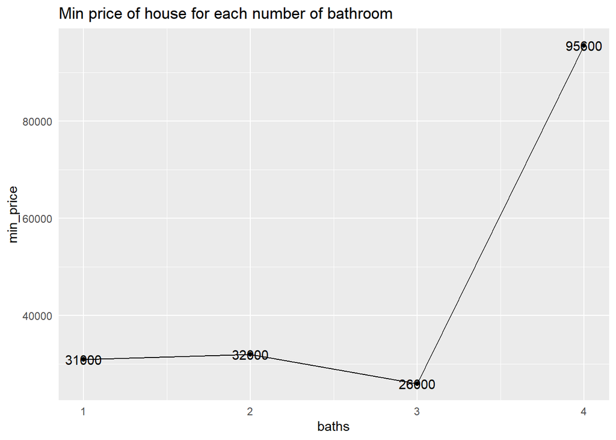

```r
#Other Graphs
ggplot(aes(x = baths, y = min_price), data = data4) + geom_line()+geom_point()+ggtitle("Min price of house for each number of bathroom")  +  geom_text(aes(label = signif(min_price, digits = 3), nudge_y = 1))+theme(axis.ticks =element_blank())
```

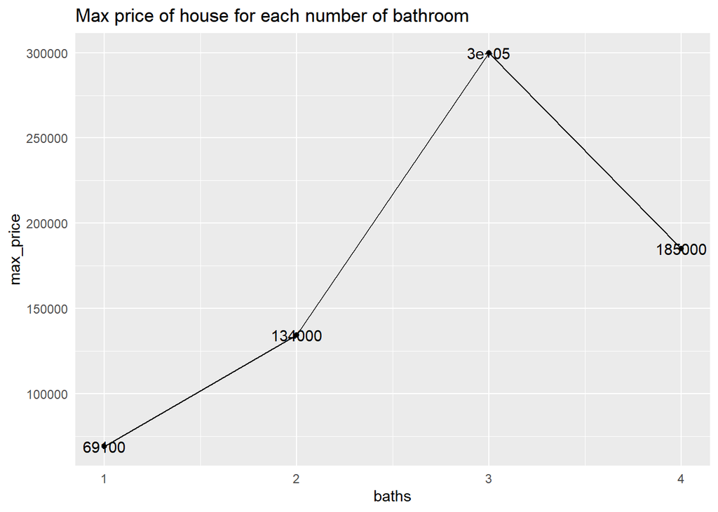

```r
ggplot(aes(x = baths, y = max_price), data = data4) + geom_line()+geom_point()+ggtitle("Max price of house for each number of bathroom")+ geom_text(aes(label = signif(max_price, digits = 3), nudge_y = 1)) + theme(axis.ticks =element_blank())
```

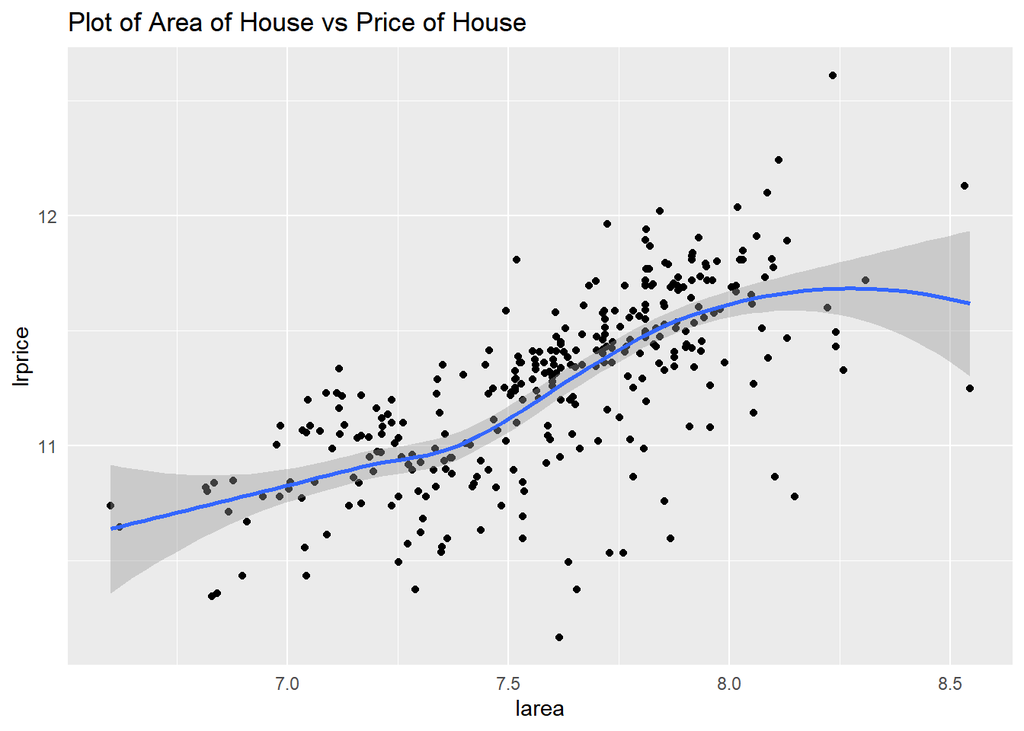

```r
ggplot(aes(x = larea, y = lrprice), data = data1) + geom_point()+geom_smooth()+ggtitle("Plot of Area of House vs Price of House")  + theme(axis.ticks =element_blank())
```

Interpretation - Price of House increases with increase in area of house

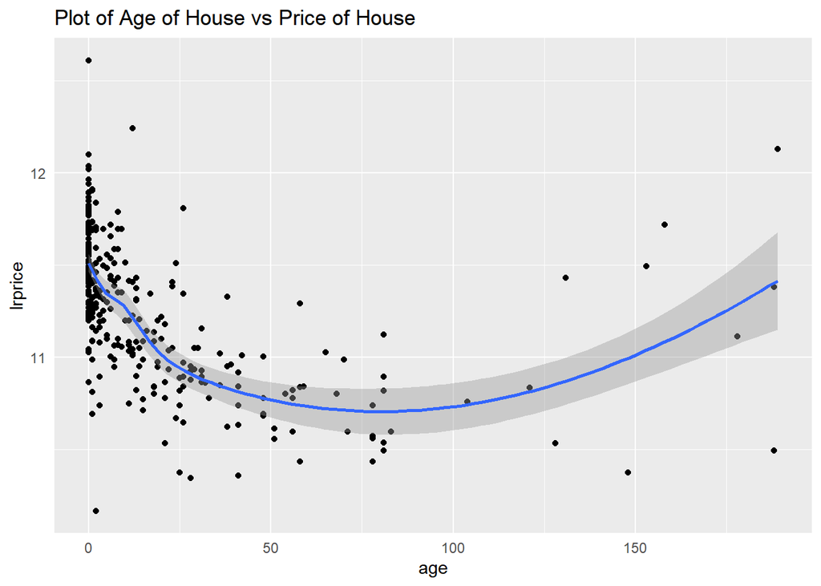

```r
ggplot(aes(x = age, y = lrprice), data = data1) + geom_point()+geom_smooth()+ggtitle("Plot of Age of House vs Price of House")  + theme(axis.ticks =element_blank())
```

Interpretation - Price of House decreases with increase in age of house upto the age of 75-80 years then starts increasing

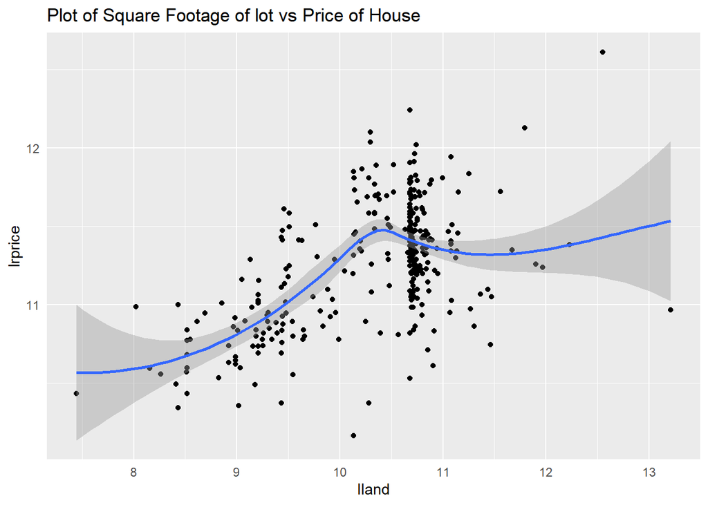

```r
ggplot(aes(x = lland, y = lrprice), data = data1) + geom_point()+geom_smooth()+ggtitle("Plot of Square Footage of lot vs Price of House")  + theme(axis.ticks =element_blank())
```

Interpretation - Price of House increases with increase in square footage of land upto the value where log(land) is around 10.2 then decreases and again starts increasing

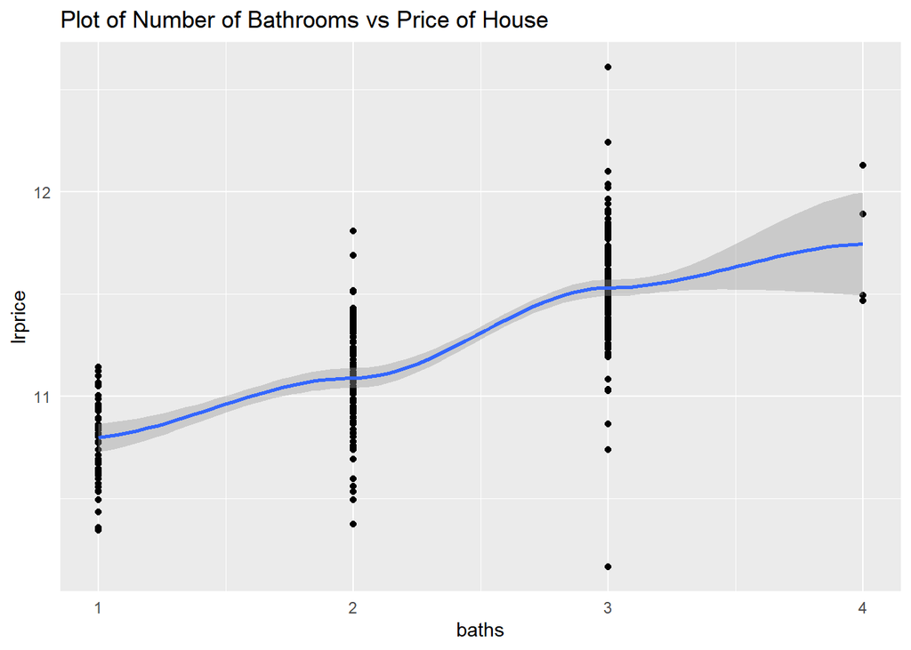

```r
ggplot(aes(x = baths, y = lrprice), data = data1) + geom_point()+geom_smooth()+ggtitle("Plot of Number of Bathrooms vs Price of House")  + theme(axis.ticks =element_blank())
```

Interpretation - Price of House increases with increase in number of bathrooms